# Analysing the effect of land-use type on honeybee foraging distances

Joseph Palmer

# TLDR

Land-use type appears to have a significant interaction with the average foraging distance of a colony. This relationship is only apparent when we subset the data to a season level and shows landscapes which are typically nutrient rich require travelling short distances than those which are typically nutrient poor.

# Overview

From Samuelson *et al*. (2021) we know that honeybees in agri-rural environments travel further when foraging than their urban counterparts. This is also evident in the data when comparing the foraging distances. As we have land-use data for these different sites it would be interesting to know what land-use types most correlate / influence the average foraging distances for a colony. To do this, I perform a regression between the average foraging distance in a given site and the principle axis of variation in land-use type across the different sites in both the urban and agri-rural environment. Please note that the term average here refers to a measure of central tendency and not exclusively the mean. In addition to evaluating to what extent the principle axis of land-use variation influences the average foraging distance of the site, I also identify the principle components which best describe the variation in average foraging distance and evaluate their relationship in both the urban and agri-rural environment. In addition to performing this on the urban and agri-rural sites, I also evaluate the relationship between land-use type and average foraging distance with the data subset by year and season.

As a start, lets first look at the foraging distances within each site.

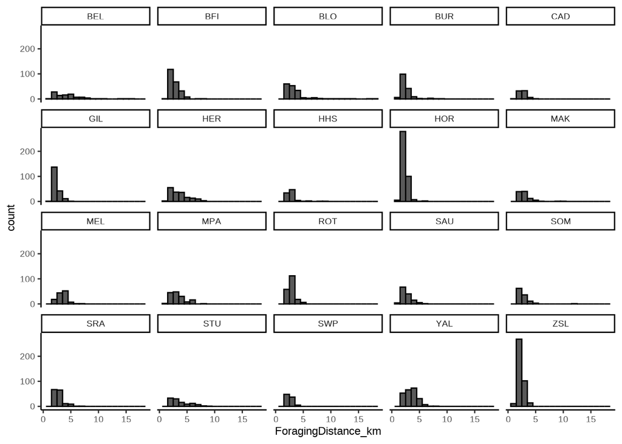

```r
# get the data
# Load land use data taken (taken from Samuelson et al. 2021)
urban_lu <- read.csv(file = "data/urban-landuse.csv")
rural_lu <- read.csv(file = "data/agri-rural-landuse.csv")

# foraging distance data
df <- read.csv("data/FullHBForagingData.csv")

ggplot(df, aes(x = ForagingDistance_km), fill = LU) +
  geom_histogram(binwidth = 1, colour = "black") +
  facet_wrap(~site)
```

In all cases the distributions are right skewed suggesting the median should be used instead of the mean as a measure of central tendency of the data.

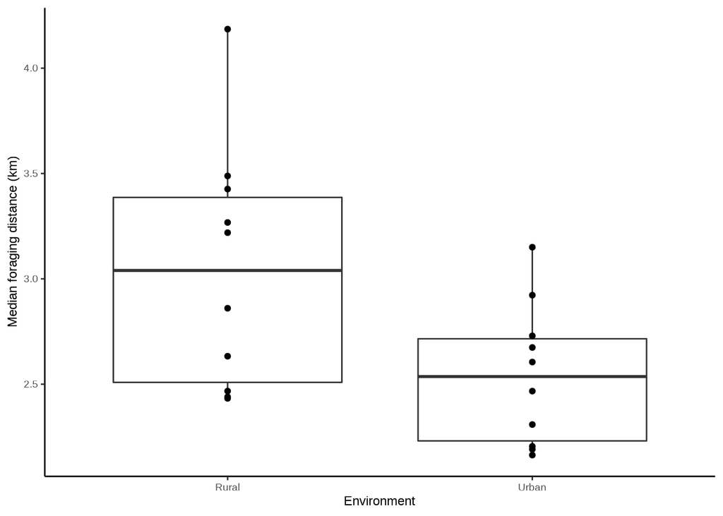

```r
# calculate median foraging distances for each site
df.median.fd <- df %>%
  group_by(LU, site) %>%
  summarise(Avg.foraging.distance = median(ForagingDistance_km))

# add land-use types to the foraging data
rural.df <- df.median.fd %>%
  filter(LU == "Rural") %>%
  inner_join(rural_lu)

urban.df <- df.median.fd %>%
  filter(LU == "Urban") %>%
  inner_join(urban_lu)

# plot median foraging distances for each environment
df.median.fd %>%
  ggplot(aes(x = LU, y = Avg.foraging.distance)) +
  geom_boxplot() +
  geom_point() +
  ylab("Median foraging distance (km)") +
  xlab("Environment")
```

From a rough eyeball the hives in the agri-rural sites do appear to be foraging on average much further than those in the urban sites. I will now evaluate the land-use factors (if any) which may influence foraging distances in the urban and agri-rural sites, starting with urban.

# Urban

## PCA

```r
urban.pcadata <- urban.df[, 4 : ncol(urban.df)]

# run PCA
upca <- prcomp(
  urban.pcadata,
  center = TRUE, scale. = TRUE
)
print(upca)
```

```
#> Standard deviations (1, .., p=8):
#> [1] 1.90766458 1.33812009 1.09646950 0.80884993 0.65628837 0.44349199 0.29388299
#> [8] 0.00036256
#>
#> Rotation (n x k) = (8 x 8):
#>                                     PC1          PC2         PC3         PC4
#> continuous..central         -0.39088080  0.216834742 -0.06357414  0.63385321
#> dense.residential           -0.42687608  0.006903623  0.29172891 -0.54591591
#> sparse.residential           0.47242445  0.062767231 -0.35674469 -0.06387666
#> parks.allotments.cemeteries  0.25716818  0.266521267  0.54314311  0.43629076
#> amenity.grassland            0.42671920 -0.346042614  0.07708896 -0.03398662
#> Railway                     -0.07386089 -0.618367993 -0.34833030  0.29926062
#> woodland                     0.14492558 -0.472043332  0.59964779  0.07087016
#> water                       -0.40880380 -0.391167931  0.04155944  0.10020722
#>                                    PC5        PC6         PC7        PC8
#> continuous..central         -0.4478345  0.1674038  0.04603252 0.40457949
#> dense.residential            0.1533928  0.3815291 -0.09062263 0.50724051
#> sparse.residential           0.1161676 -0.3122563 -0.02835211 0.72782256
#> parks.allotments.cemeteries  0.5865377  0.1514945  0.05245403 0.08802489
#> amenity.grassland           -0.2742460  0.5212051  0.58151891 0.07770167
#> Railway                      0.3550457  0.3437075 -0.39502581 0.03220278
#> woodland                    -0.3630104 -0.3264733 -0.36129858 0.15057753
#> water                        0.2921449 -0.4578018  0.60113807 0.10862910
```

```r
print(summary(upca))
```

```
#> Importance of components:
#>                           PC1    PC2    PC3     PC4     PC5     PC6    PC7
#> Standard deviation     1.9077 1.3381 1.0965 0.80885 0.65629 0.44349 0.2939
#> Proportion of Variance 0.4549 0.2238 0.1503 0.08178 0.05384 0.02459 0.0108
#> Cumulative Proportion  0.4549 0.6787 0.8290 0.91078 0.96462 0.98920 1.0000
#>                              PC8
#> Standard deviation     0.0003626
#> Proportion of Variance 0.0000000
#> Cumulative Proportion  1.0000000
```

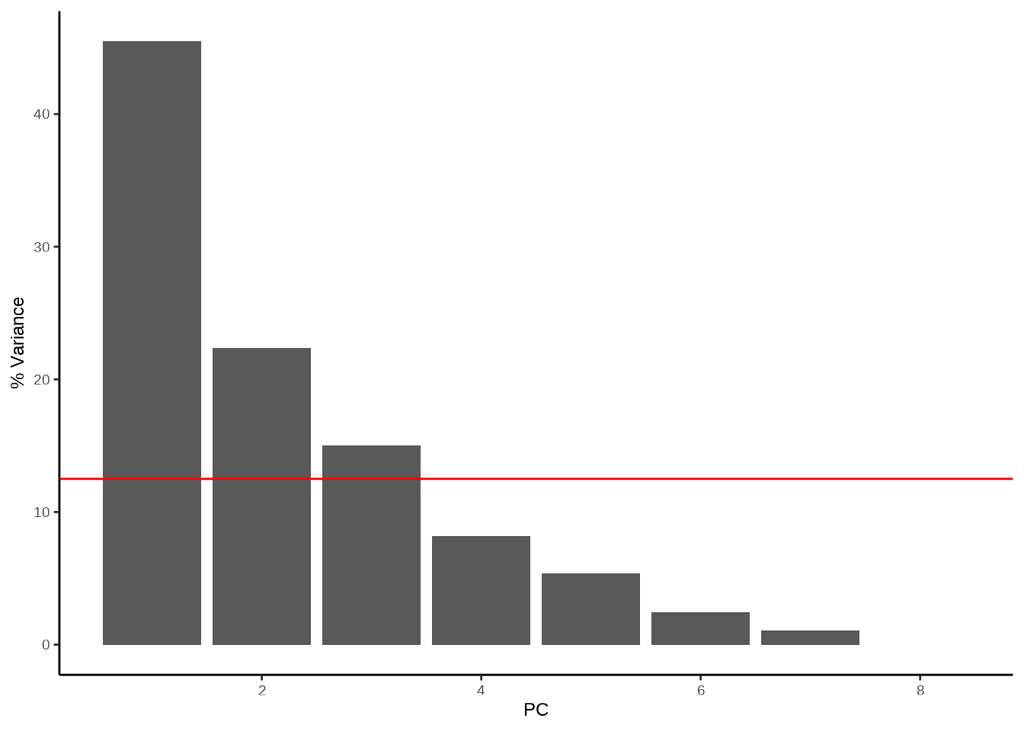

```r
# extract the sd, loadings and scores of the data
sd <- upca$sdev
loadings <- upca$rotation
rownames(loadings) <- colnames(urban.pcadata)
scores <- upca$x

# calculate the variance and percentage of overall variances directly
var <- sd^2
varpercent <- var / sum(var) * 100

# make a scree plot
ggplot(
  data.frame(PC = seq(1, 8), varpercent = varpercent),
  aes(x = PC, y = varpercent)
) +
  geom_bar(stat = "identity") +
  geom_hline(yintercept = 1 / ncol(urban.pcadata) * 100, col = "red") +
  ylab("% Variance")
```

The red line on the plot indicates the expected variance each PC should contribute if they all contributed equally. PCs 1, 2 and 3 explain ~83% of the variance in the data. The loadings can now be evaluated for each of these PCs to identify how each land-use type contributes to the variance in each PC. Again, we can use the expected variance from each land-use if they all equally contributed to find a cut-off.

```r
print(loadings[, 1:3])
```

```
#>                                     PC1          PC2         PC3
#> continuous..central         -0.39088080  0.216834742 -0.06357414
#> dense.residential           -0.42687608  0.006903623  0.29172891
#> sparse.residential           0.47242445  0.062767231 -0.35674469
#> parks.allotments.cemeteries  0.25716818  0.266521267  0.54314311
#> amenity.grassland            0.42671920 -0.346042614  0.07708896
#> Railway                     -0.07386089 -0.618367993 -0.34833030
#> woodland                     0.14492558 -0.472043332  0.59964779
#> water                       -0.40880380 -0.391167931  0.04155944
```

```r
sqrt(1 / ncol(urban.pcadata)) # cut off for top loadings
```

```
#> [1] 0.3535534
```

The expected variance each should contribute is around 0.35 and so any values smaller than -0.35 and larger than 0.35 can be said to be contributing more than expected to the variance than under a null model and are thus the main contributors to that PC.

The table shows that continuous central, dense residential and water correlates negatively with PC1, whilst sparse residential and amenity grassland correlates positively with PC1. For PC2 the main contributors are railway, woodland and water, all of which have negative relationships. For PC3, the main variables are sparse residential and railway having a negative correlation with PC3, whilst parks, allotments and cemeteries and woodland all have positive correlations.

These PCs all show the factors that most explain the variance within land-use types across our study sites. To see how this influences the average foraging distance I will now perform a regression of these Principle components.

## PCA + regression

```r
mydata <- cbind(
  Avg.foraging.distance = urban.df$Avg.foraging.distance, data.frame(upca$x)
)

mydata.mod.3 <- lm(
  Avg.foraging.distance ~ PC1 + PC2 + PC3,
  data = mydata
)
summary(mydata.mod.3)
```

```
#>
#> Call:
#> lm(formula = Avg.foraging.distance ~ PC1 + PC2 + PC3, data = mydata)
#>
#> Residuals:
#>      Min       1Q   Median       3Q      Max
#> -0.35729 -0.27456 -0.06323  0.20218  0.64079
#>
#> Coefficients:
#>             Estimate Std. Error t value Pr(>|t|)
#> (Intercept)  2.54172    0.12827  19.815 1.07e-06 ***
#> PC1         -0.01898    0.07088  -0.268    0.798
#> PC2         -0.01257    0.10104  -0.124    0.905
#> PC3         -0.03021    0.12331  -0.245    0.815
#> ---
#> Signif. codes:  0 '***' 0.001 '**' 0.01 '*' 0.05 '.' 0.1 ' ' 1
#>
#> Residual standard error: 0.4056 on 6 degrees of freedom
#> Multiple R-squared:  0.02395,    Adjusted R-squared:  -0.4641
#> F-statistic: 0.04907 on 3 and 6 DF,  p-value: 0.9843
```

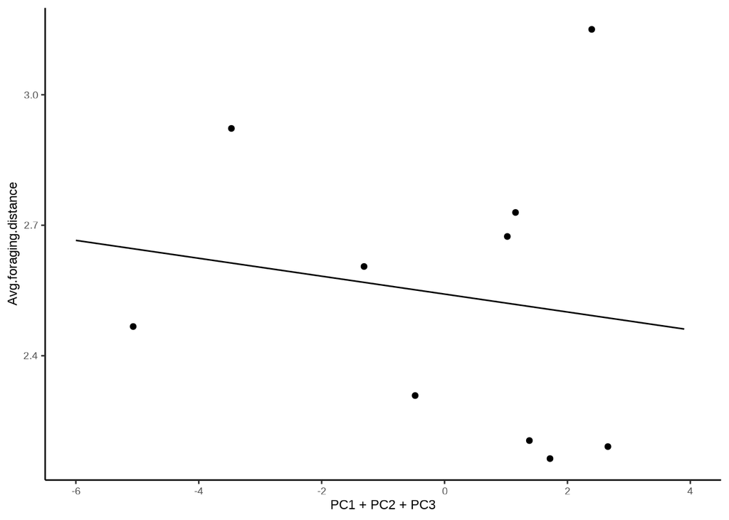

```r
newdat <- data_frame(
  PC1 = seq(-5, 4, 0.1),
  PC2 = seq(-5, 4, 0.1),
  PC3 = seq(-5, 4, 0.1),
)

newdat$fit <- predict(mydata.mod.3, newdat, type = "response")

plotdata <- mydata

ggplot(data = plotdata, aes(x = PC1 + PC2 + PC3, y = Avg.foraging.distance)) +
  geom_point() +
  geom_line(data = newdat, aes(x = PC1 + PC2 + PC3, y = fit)) +
  xlim(-6, 4)
```

Whilst the intercept is significantly different to 0 their is no significant relationship between the average foraging distance and the main axis of variation in land-use type.

## PLS

Using a PLS we can evaluate what land-use types most explain the variation in the average foraging distances across the urban sites.

```r
urban.plsdata <- urban.df[, 3:ncol(urban.df)]

model <- plsRglm(
  Avg.foraging.distance ~ .,
  data = urban.plsdata,
  nt = ncol(urban.plsdata) - 1,
  verbose = FALSE
)

model
```

```
#> Number of required components:
#> [1] 8
#> Number of successfully computed components:
#> [1] 8
#> Coefficients:
#>                                   [,1]
#> Intercept                   1226.79921
#> continuous..central          -12.22251
#> dense.residential            -12.28201
#> sparse.residential           -12.29101
#> parks.allotments.cemeteries  -11.96918
#> amenity.grassland            -12.07654
#> Railway                      -11.87258
#> woodland                     -12.32749
#> water                        -12.29970
#> Information criteria and Fit statistics:
#>                 AIC     RSS_Y      R2_Y R2_residY RSS_residY  AIC.std  DoF.dof
#> Nb_Comp_0  9.466352 1.0114078        NA        NA   9.000000 31.32517 1.000000
#> Nb_Comp_1  6.855018 0.6377620 0.3694314 0.3694314   5.675117 28.71383 7.119678
#> Nb_Comp_2  6.220931 0.4900740 0.5154536 0.5154536   4.360918 28.07974 7.646437
#> Nb_Comp_3  7.947815 0.4768704 0.5285082 0.5285082   4.243426 29.80663 6.684661
#> Nb_Comp_4  9.684116 0.4644597 0.5407790 0.5407790   4.132989 31.54293 7.244896
#> Nb_Comp_5 11.587548 0.4599961 0.5451922 0.5451922   4.093270 33.44636 7.739058
#> Nb_Comp_6 13.582487 0.4597634 0.5454223 0.5454223   4.091199 35.44130 7.746359
#> Nb_Comp_7 15.580020 0.4596500 0.5455345 0.5455345   4.090190 37.43883 7.999126
#> Nb_Comp_8 11.707442 0.2554962 0.7473856 0.7473856   2.273530 33.56626 9.000000
#>           sigmahat.dof   AIC.dof   BIC.dof  GMDL.dof DoF.naive sigmahat.naive
#> Nb_Comp_0    0.3352292 0.1236165 0.1270169 -6.601040         1      0.3352292
#> Nb_Comp_1    0.4054109 0.2978114 0.3332192  6.422198         2      0.2823477
#> Nb_Comp_2    0.3822765 0.2724903 0.3063016  7.077662         3      0.2645951
#> Nb_Comp_3    0.3324243 0.1954260 0.2177778  5.109424         4      0.2819191
#> Nb_Comp_4    0.3516924 0.2256667 0.2527814  6.228560         5      0.3047818
#> Nb_Comp_5    0.3755827 0.2643376 0.2973705  7.181184         6      0.3391151
#> Nb_Comp_6    0.3759087 0.2648998 0.2980213  7.194427         7      0.3914773
#> Nb_Comp_7    0.3913720 0.2910134 0.3280874  7.663119         8      0.4794007
#> Nb_Comp_8    0.3574187 0.2554962 0.2902854  9.044485         9      0.5054663
#>            AIC.naive  BIC.naive GMDL.naive
#> Nb_Comp_0 0.12361651 0.12701692 -6.6010400
#> Nb_Comp_1 0.09566430 0.10048873 -5.4847472
#> Nb_Comp_2 0.09101374 0.09736899 -3.5390507
#> Nb_Comp_3 0.11126977 0.12088936 -0.8650914
#> Nb_Comp_4 0.13933792 0.15339178  1.6286464
#> Nb_Comp_5 0.18399846 0.20487665  3.9806498
#> Nb_Comp_6 0.26053259 0.29299335  6.1458180
#> Nb_Comp_7 0.41368499 0.46931829  8.0701754
#> Nb_Comp_8 0.48544278 0.55502119  9.3910581
```

The PLS results indicate the first 4 PCs explain 54% of the variation in the average foraging distance. The four PCs are characterised as follows:

```r
print(model$pp[, 1:4])
```

```
#>                                 Comp_1      Comp_2     Comp_3     Comp_4
#> continuous..central          0.8354152 -0.14409772  0.3929372 -0.2108624
#> dense.residential            0.1456911 -0.60669293  0.2477157  0.3346872
#> sparse.residential          -0.5622956  0.44412714 -0.3263759 -0.3769797
#> parks.allotments.cemeteries -0.2395906  0.34338928  0.6120456 -0.0901554
#> amenity.grassland           -0.4616796  0.41491873 -0.2917280  0.7104547
#> Railway                      0.4580495  0.06290916 -0.7529820  0.5711643
#> woodland                    -0.1678151  0.12660287 -0.1064425  0.7260458
#> water                        0.5969033 -0.37525509 -0.3499387  0.1374505
```

```r
sqrt(1 / (ncol(urban.plsdata) - 1))
```

```
#> [1] 0.3535534
```

Values greater than 0.35 or less -0.35 can be said to be contributing more towards the variance than would be expected under a null model. PC1 shows a positive correlation with continuous central, railway and water, and a negative correlation with sparse residential and amenity grassland. PC2 shows a positive correlation sparse residential and amenity grassland and a negative correlation with water and dense residential. PC3 shows a positive correlation with continuous central, parks allotments and cemeteries, and a negative correlation with railway. PC4 describes a positive correlation with amenity grassland, railway and woodland, and a negative relationship with sparse residential.

We can pull out the coefficients to see what this relationship looks like graphically.

```r
plsdata <- data.frame(
  Avg.foraging.distance = model$dataY,
  model$tt
)

plsmodel <- lm(
  Avg.foraging.distance ~ Comp_1 + Comp_2 + Comp_3 + Comp_4,
  plsdata
)

summary(plsmodel)
```

```
#>
#> Call:
#> lm(formula = Avg.foraging.distance ~ Comp_1 + Comp_2 + Comp_3 +
#>     Comp_4, data = plsdata)
#>
#> Residuals:
#>        1        2        3        4        5        6        7        8
#>  0.05914  0.08123  0.04147  0.11286  0.10802 -0.17882  0.01675  0.36826
#>        9       10
#> -0.11084 -0.49808
#>
#> Coefficients:
#>             Estimate Std. Error t value Pr(>|t|)
#> (Intercept)  2.54172    0.09638  26.372 1.47e-06 ***
#> Comp_1       0.20273    0.10108   2.006    0.101
#> Comp_2       0.08446    0.06698   1.261    0.263
#> Comp_3       0.03927    0.10417   0.377    0.722
#> Comp_4       0.05313    0.14536   0.366    0.730
#> ---
#> Signif. codes:  0 '***' 0.001 '**' 0.01 '*' 0.05 '.' 0.1 ' ' 1
#>
#> Residual standard error: 0.3048 on 5 degrees of freedom
#> Multiple R-squared:  0.5408, Adjusted R-squared:  0.1734
#> F-statistic: 1.472 on 4 and 5 DF,  p-value: 0.3361
```

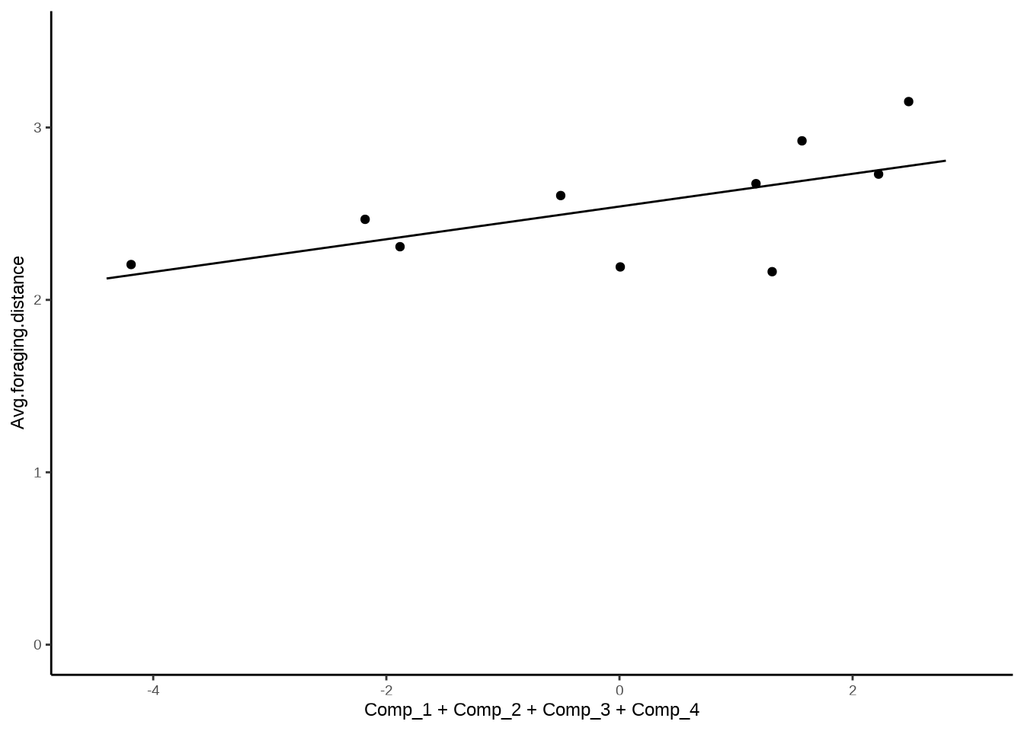

```r
newdat <- data_frame(
  Comp_1 = seq(-50, 140, 0.1),
  Comp_2 = seq(-50, 140, 0.1),
  Comp_3 = seq(-50, 140, 0.1),
  Comp_4 = seq(-50, 140, 0.1)
)

newdat$fit <- predict(plsmodel, newdat, type = "response")

plotdata <- plsdata

ggplot(
  data = plotdata,
  aes(x = Comp_1 + Comp_2 + Comp_3 + Comp_4, y = Avg.foraging.distance)
  ) +
  geom_point() +
  geom_line(
    data = newdat, aes(x = Comp_1 + Comp_2 + Comp_3 + Comp_4, y = fit)
  ) +
  xlim(min(-4.5), max(3)) +
  ylim(0, 3.5)
```

Although the fit is much better than with the PCA and the intercept is significantly different to 0, there is no significant relationship between the PCs and the median foraging distances reported across the different sites. This suggests the land-use types we have recorded do not explain foraging distances in the urban environment.

Could do some kind of GLM maybe instead?

# Agri-rural

## PCA

```r
rural.pcadata <- rural.df[, 4 : ncol(rural.df)]

# run PCA
rpca <- prcomp(
  rural.pcadata,
  center = TRUE, scale. = TRUE
)
print(rpca)
```

```
#> Standard deviations (1, .., p=10):
#>  [1] 1.688289e+00 1.510986e+00 1.370671e+00 1.148249e+00 9.810679e-01
#>  [6] 7.085918e-01 4.241235e-01 1.554538e-01 2.728105e-02 7.241053e-17
#>
#> Rotation (n x k) = (10 x 10):
#>                                                PC1         PC2          PC3
#> woodland                               -0.33038882  0.11626344 -0.353385022
#> Non.agricultural.unmanaged.green.space -0.36302816  0.02738826  0.338661909
#> Non.agricultural.managed.green.space    0.17650867  0.43996873  0.372079543
#> arable                                  0.49185415  0.04504733  0.007547608
#> pasture                                 0.02618546 -0.57403080 -0.132293842
#> other.agricultural                     -0.33886825  0.39876816 -0.174811474
#> fruit                                  -0.35345023 -0.24671456 -0.085315705
#> OSR                                    -0.13012750  0.32974892 -0.552519479
#> built.up.area                          -0.23339428  0.24558560  0.416092221
#> water                                  -0.41728585 -0.26774770  0.296946110
#>                                                PC4          PC5         PC6
#> woodland                                0.30350914  0.498528806 -0.25038554
#> Non.agricultural.unmanaged.green.space -0.15327533  0.568189243  0.25388327
#> Non.agricultural.managed.green.space   -0.10796624 -0.009115998 -0.60030734
#> arable                                 -0.43326390  0.074546785  0.29525672
#> pasture                                 0.31875435 -0.194249579 -0.05120274
#> other.agricultural                     -0.04995569 -0.351748182  0.50732378
#> fruit                                  -0.48618681 -0.306937008 -0.37499672
#> OSR                                    -0.22992449 -0.083412709 -0.15573324
#> built.up.area                           0.41171759 -0.399852017  0.01549636
#> water                                  -0.34951450 -0.021917227  0.01379390
#>                                                PC7         PC8          PC9
#> woodland                                0.41179544 -0.17362272 -0.137684093
#> Non.agricultural.unmanaged.green.space -0.40434096  0.39078525  0.001729096
#> Non.agricultural.managed.green.space   -0.25915737 -0.15370211 -0.391646458
#> arable                                  0.22374941 -0.05758352  0.056043130
#> pasture                                -0.47812725 -0.06353913 -0.253126699
#> other.agricultural                     -0.03505516 -0.08717736 -0.547412512
#> fruit                                   0.26532631  0.48398847 -0.119691142
#> OSR                                    -0.47765881 -0.08066341  0.484420061
#> built.up.area                           0.14436789  0.12408404  0.437736387
#> water                                   0.02177035 -0.72278382  0.142045158
#>                                               PC10
#> woodland                               -0.36114559
#> Non.agricultural.unmanaged.green.space -0.16053593
#> Non.agricultural.managed.green.space   -0.14334041
#> arable                                 -0.64731863
#> pasture                                -0.46219728
#> other.agricultural                     -0.05919647
#> fruit                                  -0.12940924
#> OSR                                    -0.12510635
#> built.up.area                          -0.39318807
#> water                                  -0.01041338
```

```r
print(summary(rpca))
```

```
#> Importance of components:
#>                          PC1    PC2    PC3    PC4     PC5     PC6     PC7
#> Standard deviation     1.688 1.5110 1.3707 1.1482 0.98107 0.70859 0.42412
#> Proportion of Variance 0.285 0.2283 0.1879 0.1318 0.09625 0.05021 0.01799
#> Cumulative Proportion  0.285 0.5133 0.7012 0.8331 0.92931 0.97952 0.99751
#>                            PC8     PC9      PC10
#> Standard deviation     0.15545 0.02728 7.241e-17
#> Proportion of Variance 0.00242 0.00007 0.000e+00
#> Cumulative Proportion  0.99993 1.00000 1.000e+00
```

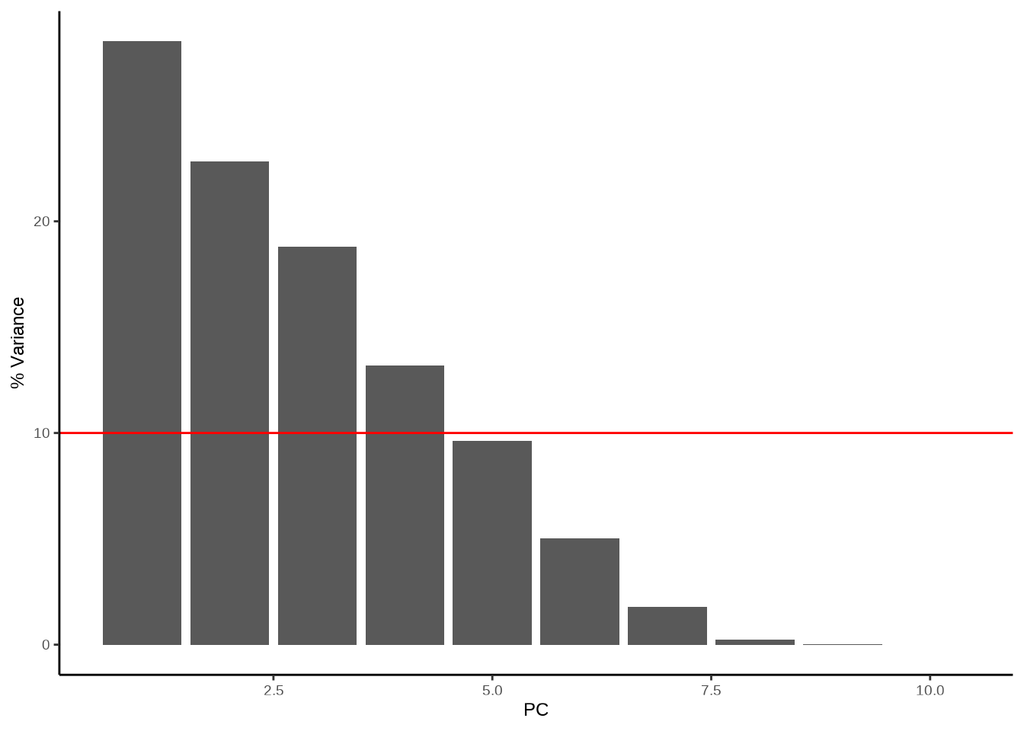

```r
# extract the sd, loadings and scores of the data
sd <- rpca$sdev
loadings <- rpca$rotation
rownames(loadings) <- colnames(rural.pcadata)
scores <- rpca$x

# calculate the variance and percentage of overall variances directly
var <- sd^2
varpercent <- var / sum(var) * 100

# make a scree plot
ggplot(
  data.frame(PC = seq(1, 10), varpercent = varpercent),
  aes(x = PC, y = varpercent)
) +
  geom_bar(stat = "identity") +
  geom_hline(yintercept = 1 / ncol(rural.pcadata) * 100, col = "red") +
  ylab("% Variance")
```

The red line on the plot indicates the expected variance each PC should contribute if they all contributed equally. PCs 1, 2, 3 and 4 explain ~83% of the variance in the data. The loadings can now be evaluated for each of these PCs to identify how each land-use type contributes to the variance in each PC. Again, we can use the expected variance from each land-use if they all equally contributed to find a cut-off.

```r
print(loadings[, 1:3])
```

```
#>                                                PC1         PC2          PC3
#> woodland                               -0.33038882  0.11626344 -0.353385022
#> Non.agricultural.unmanaged.green.space -0.36302816  0.02738826  0.338661909
#> Non.agricultural.managed.green.space    0.17650867  0.43996873  0.372079543
#> arable                                  0.49185415  0.04504733  0.007547608
#> pasture                                 0.02618546 -0.57403080 -0.132293842
#> other.agricultural                     -0.33886825  0.39876816 -0.174811474
#> fruit                                  -0.35345023 -0.24671456 -0.085315705
#> OSR                                    -0.13012750  0.32974892 -0.552519479
#> built.up.area                          -0.23339428  0.24558560  0.416092221
#> water                                  -0.41728585 -0.26774770  0.296946110
```

```r
sqrt(1 / ncol(rural.pcadata)) # cut off for top loadings
```

```
#> [1] 0.3162278
```

The expected variance each should contribute is around 0.32 and so any values smaller than -0.32 and larger than 0.32 can be said to be contributing more than expected to the variance than under a null model and are thus the main contributors to that PC.

## PCA + regression

```r
mydata <- cbind(
  Avg.foraging.distance = rural.df$Avg.foraging.distance, data.frame(rpca$x)
)

mydata.mod.3 <- lm(
  Avg.foraging.distance ~ PC1 + PC2 + PC3 + PC4,
  data = mydata
)
summary(mydata.mod.3)
```

```
#>
#> Call:
#> lm(formula = Avg.foraging.distance ~ PC1 + PC2 + PC3 + PC4, data = mydata)
#>
#> Residuals:
#>         1         2         3         4         5         6         7         8
#>  0.451354 -0.225457 -0.159818  0.500322 -0.228087 -0.185816 -0.708042 -0.003987
#>         9        10
#>  0.641550 -0.082019
#>
#> Coefficients:
#>              Estimate Std. Error t value Pr(>|t|)
#> (Intercept)  3.041970   0.175307  17.352 1.16e-05 ***
#> PC1         -0.006508   0.109454  -0.059   0.9549
#> PC2          0.057272   0.122297   0.468   0.6593
#> PC3         -0.040120   0.134817  -0.298   0.7780
#> PC4         -0.339662   0.160931  -2.111   0.0886 .
#> ---
#> Signif. codes:  0 '***' 0.001 '**' 0.01 '*' 0.05 '.' 0.1 ' ' 1
#>
#> Residual standard error: 0.5544 on 5 degrees of freedom
#> Multiple R-squared:  0.488,  Adjusted R-squared:  0.07844
#> F-statistic: 1.192 on 4 and 5 DF,  p-value: 0.4164
```

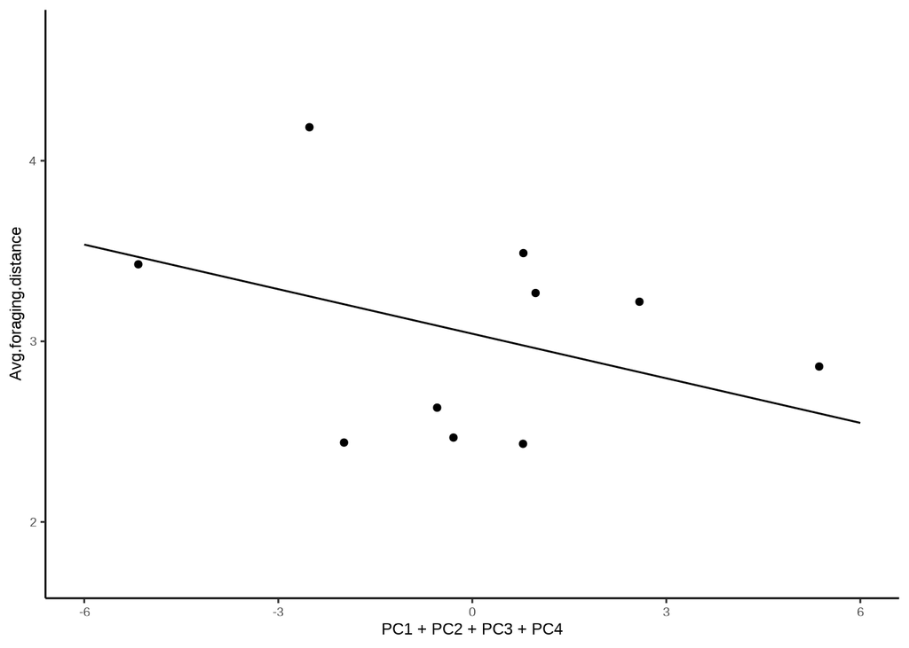

```r
newdat <- data_frame(
  PC1 = seq(-5, 4, 0.1),
  PC2 = seq(-5, 4, 0.1),
  PC3 = seq(-5, 4, 0.1),
  PC4 = seq(-5, 4, 0.1),
)

newdat$fit <- predict(mydata.mod.3, newdat, type = "response")

plotdata <- mydata

ggplot(
  data = plotdata,
  aes(x = PC1 + PC2 + PC3 + PC4, y = Avg.foraging.distance)
  ) +
  geom_point() +
  geom_line(data = newdat, aes(x = PC1 + PC2 + PC3 + PC4, y = fit)) +
  xlim(min(-6), max(6))
```

Whilst the intercept is significantly different to 0 their is no significant relationship between the average foraging distance and the main axis of variation in land-use type.

## PLS

```r
rural.plsdata <- rural.df[, 3:ncol(rural.df)]

model <- plsRglm(
  Avg.foraging.distance ~ .,
  data = rural.plsdata,
  nt = ncol(rural.plsdata) - 1,
  verbose = FALSE
)

model
```

```
#> Number of required components:
#> [1] 10
#> Number of successfully computed components:
#> [1] 9
#> Coefficients:
#>                                               [,1]
#> Intercept                              -0.65109786
#> woodland                                0.06058089
#> Non.agricultural.unmanaged.green.space  0.09073271
#> Non.agricultural.managed.green.space    0.76841460
#> arable                                 -0.01794739
#> pasture                                 0.15619416
#> other.agricultural                      3.04549874
#> fruit                                   0.15897810
#> OSR                                    -0.77945388
#> built.up.area                          -0.30729200
#> water                                  -2.70331616
#> Information criteria and Fit statistics:
#>                   AIC        RSS_Y      R2_Y R2_residY   RSS_residY    AIC.std
#> Nb_Comp_0   20.343505 3.001339e+00        NA        NA 9.000000e+00   31.32517
#> Nb_Comp_1   12.151977 1.083185e+00 0.6390994 0.6390994 3.248105e+00   23.13364
#> Nb_Comp_2   11.004597 7.907035e-01 0.7365498 0.7365498 2.371052e+00   21.98626
#> Nb_Comp_3    6.870992 4.281881e-01 0.8573343 0.8573343 1.283991e+00   17.85265
#> Nb_Comp_4    6.994554 3.549293e-01 0.8817430 0.8817430 1.064313e+00   17.97621
#> Nb_Comp_5    7.489334 3.053311e-01 0.8982684 0.8982684 9.155846e-01   18.47099
#> Nb_Comp_6    9.069617 2.927810e-01 0.9024499 0.9024499 8.779512e-01   20.05128
#> Nb_Comp_7   10.946034 2.891850e-01 0.9036480 0.9036480 8.671680e-01   21.92769
#> Nb_Comp_8   11.560210 2.517620e-01 0.9161168 0.9161168 7.549491e-01   22.54187
#> Nb_Comp_9 -635.113731 1.696051e-29 1.0000000 1.0000000 5.000225e-29 -624.30193
#>            DoF.dof sigmahat.dof      AIC.dof      BIC.dof   GMDL.dof DoF.naive
#> Nb_Comp_0 1.000000 5.774791e-01 3.668303e-01 3.769210e-01  -1.526657         1
#> Nb_Comp_1 8.688330 6.845235e-01 9.225408e-01 1.045727e+00  11.019877         2
#> Nb_Comp_2 5.605134 3.828393e-01 2.433747e-01 2.682327e-01   4.855925         3
#> Nb_Comp_3 9.000000 4.627030e-01 4.281881e-01 4.864915e-01  10.990717         4
#> Nb_Comp_4 9.000000 4.212655e-01 3.549293e-01 4.032577e-01  10.900359         5
#> Nb_Comp_5 7.819589 3.098446e-01 1.806749e-01 2.033902e-01   8.369782         6
#> Nb_Comp_6 8.396372 3.353374e-01 2.181145e-01 2.466841e-01   9.595049         7
#> Nb_Comp_7 8.235363 3.234215e-01 2.012047e-01 2.272703e-01   9.239648         8
#> Nb_Comp_8 7.942372 2.869477e-01 1.559696e-01 1.757577e-01   8.449501         9
#> Nb_Comp_9 9.000000 2.912088e-15 1.696051e-29 1.926991e-29 -21.688306        10
#>           sigmahat.naive  AIC.naive BIC.naive GMDL.naive
#> Nb_Comp_0      0.5774791 0.36683034 0.3769210 -1.5266566
#> Nb_Comp_1      0.3679648 0.16247775 0.1706716 -2.9918851
#> Nb_Comp_2      0.3360917 0.14684493 0.1570987 -1.3024177
#> Nb_Comp_3      0.2671417 0.09991055 0.1085481 -0.4311065
#> Nb_Comp_4      0.2664317 0.10647880 0.1172184  1.9039945
#> Nb_Comp_5      0.2762839 0.12213244 0.1359907  4.2996508
#> Nb_Comp_6      0.3123999 0.16590926 0.1865805  6.7977540
#> Nb_Comp_7      0.3802532 0.26026651 0.2952677  9.1256254
#> Nb_Comp_8      0.5017589 0.47834783 0.5469093 11.0800908
#> Nb_Comp_9            Inf        Inf       Inf        Inf
```

The PLS results indicate the first 3 PCs explain 86% of the variation in the average foraging distance. The three PCs are characterised as follows:

```r
print(model$pp[, 1:3])
```

```
#>                                             Comp_1      Comp_2      Comp_3
#> woodland                               -0.06133451 -0.42452691  0.23137571
#> Non.agricultural.unmanaged.green.space  0.24776991  0.23440437  0.55446199
#> Non.agricultural.managed.green.space    0.16092185 -0.42679128  0.01732776
#> arable                                  0.40035266  0.28316716 -0.38695160
#> pasture                                -0.54562691  0.57797300 -0.17502696
#> other.agricultural                      0.27077831 -0.60076613  0.58424287
#> fruit                                   0.27523516  0.06858192 -0.51920424
#> OSR                                     0.47683663 -0.54042215  0.21126393
#> built.up.area                          -0.40850465 -0.46511663  0.41542692
#> water                                   0.15906714  0.34588785 -0.08103498
```

```r
sqrt(1 / (ncol(rural.plsdata) - 1))
```

```
#> [1] 0.3162278
```

Values greater than 0.32 or less -0.32 can be said to be contributing more towards the variance than would be expected under a null model. PC1 correlates positively with arable and OSR, and negatively with pasture and built up areas. PC2 correlates positively with pasture and water, but negatively with woodland, non-agricultural managed green space, other agricultural land, OSR and built up areas. PC3 correlates positively with Non agricultural unmanaged green space, other agricultural and built up areas, and negatively with arable land and fruit.

We can pull out the coefficients to see what this relationship looks like graphically.

```r
plsdata <- data.frame(
  Avg.foraging.distance = model$dataY,
  model$tt
)

plsmodel <- lm(
  Avg.foraging.distance ~ Comp_1 + Comp_2 + Comp_3,
  plsdata
)

summary(plsmodel)
```

```
#>
#> Call:
#> lm(formula = Avg.foraging.distance ~ Comp_1 + Comp_2 + Comp_3,
#>     data = plsdata)
#>
#> Residuals:
#>     Min      1Q  Median      3Q     Max
#> -0.4128 -0.1342  0.0143  0.1038  0.3738
#>
#> Coefficients:
#>             Estimate Std. Error t value Pr(>|t|)
#> (Intercept)  3.04197    0.08448  36.009 3.06e-08 ***
#> Comp_1       0.41094    0.07927   5.184  0.00205 **
#> Comp_2       0.18267    0.09023   2.024  0.08935 .
#> Comp_3       0.24924    0.11059   2.254  0.06510 .
#> ---
#> Signif. codes:  0 '***' 0.001 '**' 0.01 '*' 0.05 '.' 0.1 ' ' 1
#>
#> Residual standard error: 0.2671 on 6 degrees of freedom
#> Multiple R-squared:  0.8573, Adjusted R-squared:  0.786
#> F-statistic: 12.02 on 3 and 6 DF,  p-value: 0.006002
```

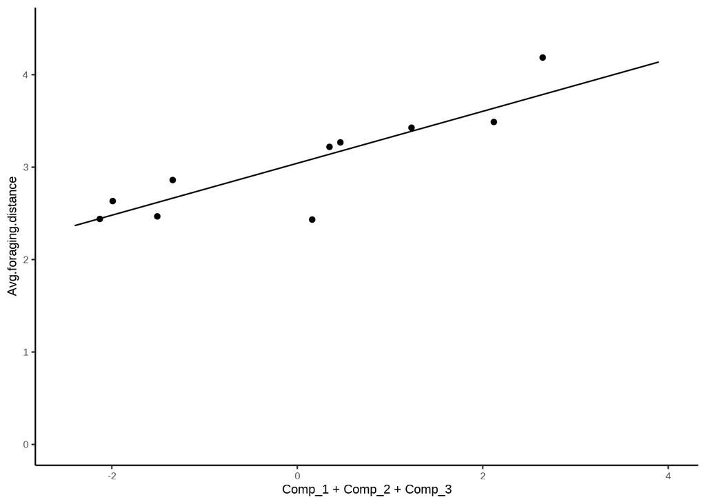

```r
newdat <- data_frame(
  Comp_1 = seq(-50, 140, 0.1),
  Comp_2 = seq(-50, 140, 0.1),
  Comp_3 = seq(-50, 140, 0.1),
)

newdat$fit <- predict(plsmodel, newdat, type = "response")

plotdata <- plsdata

ggplot(
  data = plotdata,
  aes(x = Comp_1 + Comp_2 + Comp_3, y = Avg.foraging.distance)
  ) +
  geom_point() +
  geom_line(
    data = newdat, aes(x = Comp_1 + Comp_2 + Comp_3, y = fit)
  ) +
  xlim(min(-2.5), max(4)) +
  ylim(0, 4.5)
```

In addition to the intercept being significantly different to 0, PC1 is significantly different to the intercept, with every one unit increase in PC1 corresponding to an increase of 410 meters. The other PCs do not significantly influence this association.

Plotting PC1 on its own against the average foraging distance maintains a significant relationship.

```r
plsdata <- data.frame(
  Avg.foraging.distance = model$dataY,
  model$tt
)

plsmodel.pc1 <- lm(
  Avg.foraging.distance ~ Comp_1,
  plsdata
)

summary(plsmodel.pc1)
```

```
#>
#> Call:
#> lm(formula = Avg.foraging.distance ~ Comp_1, data = plsdata)
#>
#> Residuals:
#>      Min       1Q   Median       3Q      Max
#> -0.62701 -0.17171 -0.04204  0.17498  0.70042
#>
#> Coefficients:
#>             Estimate Std. Error t value Pr(>|t|)
#> (Intercept)   3.0420     0.1164  26.143 4.92e-09 ***
#> Comp_1        0.4109     0.1092   3.764  0.00551 **
#> ---
#> Signif. codes:  0 '***' 0.001 '**' 0.01 '*' 0.05 '.' 0.1 ' ' 1
#>
#> Residual standard error: 0.368 on 8 degrees of freedom
#> Multiple R-squared:  0.6391, Adjusted R-squared:  0.594
#> F-statistic: 14.17 on 1 and 8 DF,  p-value: 0.005514
```

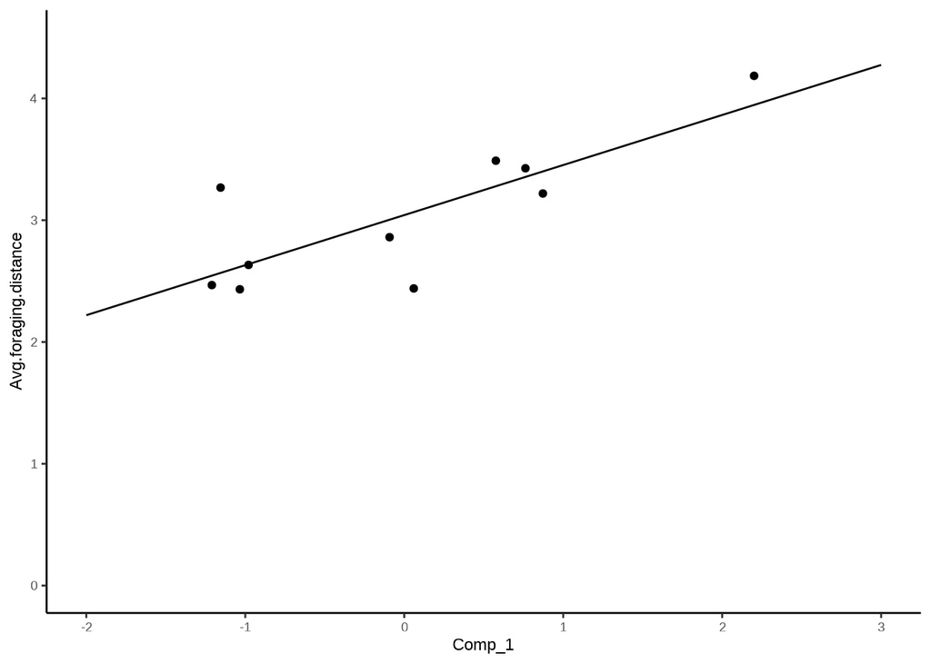

```r
newdat <- data_frame(
  Comp_1 = seq(-50, 140, 0.1),
)

newdat$fit <- predict(plsmodel.pc1, newdat, type = "response")

plotdata <- plsdata

ggplot(
  data = plotdata,
  aes(x = Comp_1, y = Avg.foraging.distance)
  ) +
  geom_point() +
  geom_line(
    data = newdat, aes(x = Comp_1, y = fit)
  ) +
  xlim(min(-2), max(3)) +
  ylim(0, 4.5)
```

Just to verify this we can perform a LRT.

```r
plsmodel.pc1_pc2 <- lm(
  Avg.foraging.distance ~ Comp_1 + Comp_2,
  plsdata
)

lrtest(plsmodel.pc1, plsmodel.pc1_pc2, plsmodel)
```

|  | #Df | LogLik | Df | Chisq | Pr(>Chisq) |
| --- | --- | --- | --- | --- | --- |
| 1 | 3 | -3.075989 | NA | NA | NA |
| 2 | 4 | -1.502299 | 1 | 3.147380 | 0.07604897 |
| 3 | 5 | 1.564504 | 1 | 6.133606 | 0.01326361 |

PC1+PC2+PC3 explains the data better than just PC1 on its own, despite these additional PCs not showing a significant relationship (although the p is not far from 0.05). The model suggests a combination of these PCs explains ~86% of the variation in average foraging distance.

# Discussion

For the urban sites there does not seem to be any effect of land-use on the median foraging distances reported by honey-bees. Whilst using a PLS regression provides a better fit than the PCA + regression, a significant effect is not identified. In the Agri-rural sites the PCA + regression did not identify any significant relationships between the main axis of land-use variation and the median foraging distance. However, the PLS regression identified a three PCs, accounting for 86% of the variation in average foraging distance, had a significant positive relationship with the average foraging distance. Of these only the first PC (explaining ~64% of the variance) was significantly different to the intercept, with every one unit increase in PC1 accounting for an increase in foraging distance of ~410 meters. This PC correlates positively with arable and OSR lands, and negatively correlated with pasture and built up areas.

One potential issue with this analysis could be that land-use types change in floral availability depending on the season. For example, gardens and parks may have more planted flowers in Spring than Summer. It is therefore prudent to investigate if season might influence foraging distance and so may influence any effects of land-use type on average foraging distance.

# Analysis over time

Unlike in the analysis of the proportion of scouts, where the model estimates are limited by the need for a significant number of data points, we can calculate an average foraging distance at practically any time scale. To break down the data, I will now repeat the PLS fitting for rural and urban sites for each years season to identify if any effect of land-use can be identified at this scale.

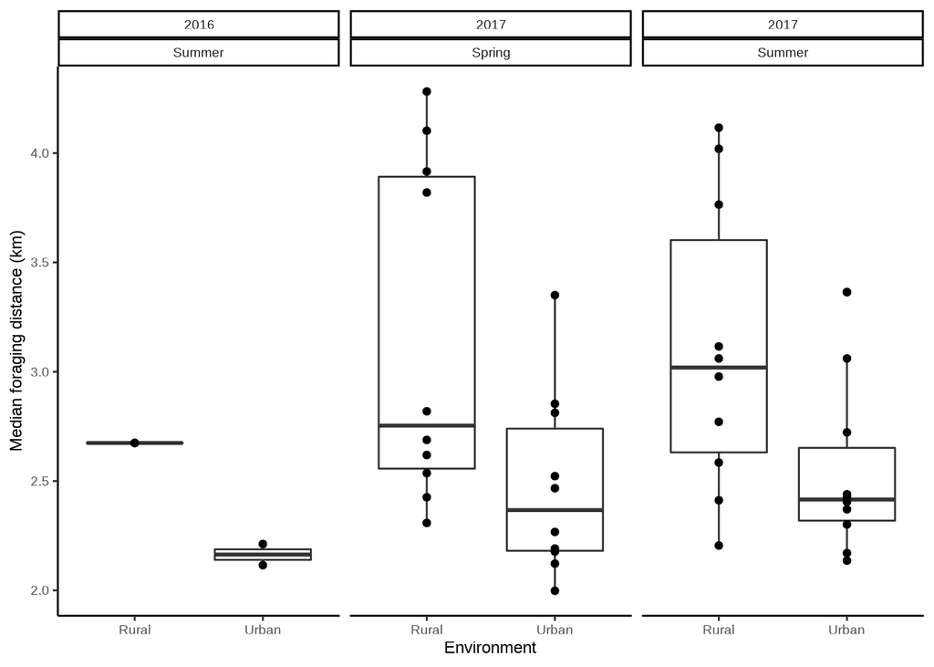

```r
# add season column
df <- df %>%
  mutate(
    season = ifelse(
      Month %in% seq(1, 3),
      "Winter",
      ifelse(
        Month %in% seq(4, 6),
        "Spring",
        ifelse(
          Month %in% seq(7, 9),
          "Summer",
          "Autumn"
        )
      )
    )
  )

# calculate mean foraging distances for each site
df.median.season.fd <- df %>%
  group_by(LU, site, Year, season) %>%
  summarise(Avg.foraging.distance = median(ForagingDistance_km))

# add land-use types to the foraging data
rural.df <- df.median.season.fd %>%
  filter(LU == "Rural") %>%
  inner_join(rural_lu, on = site)

urban.df <- df.median.season.fd %>%
  filter(LU == "Urban") %>%
  inner_join(urban_lu, on = site)

# plot mean foraging distances for each environment
df.median.season.fd %>%
  ggplot(aes(x = LU, y = Avg.foraging.distance)) +
  geom_boxplot() +
  geom_point() +
  ylab("Median foraging distance (km)") +
  xlab("Environment") +
  facet_wrap(~Year+season)
```

The trend of further foraging in agri-rural environments is consistent at the season level, however, between landscape type there doesn’t appear to be much of a difference. Agrirural foraging distances in spring have a similar spread as to those in summer and the same appears to be the case for urban also.

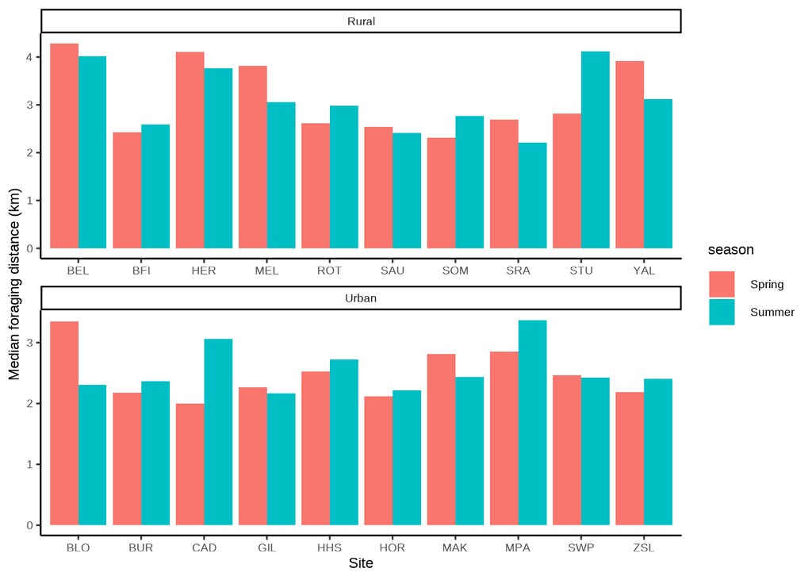

```r
df.median.season.fd %>%
  ggplot(aes(x = site, y = Avg.foraging.distance, fill = season)) +
  geom_bar(stat = "identity", position = "dodge") +
  ylab("Median foraging distance (km)") +
  xlab("Site") +
  facet_wrap(~LU, ncol = 1, scale = "free")
```

When we break this down by site we see some differences, but their doesn’t seem to be that much in it (however, this is missing confidence intervals).

Lets do a PLS on each one to see if any landscape factors emerge once we control for seasons. There only a few data points for 2016 so I will not include this and instead focus on 2017.

## Urban by season

### Spring 2017

```r
# subset data by season and year and prepare for the model
urban.df$year_season <- paste(urban.df$season, urban.df$Year, sep = "_")
seasonal.foraging.df <- purrr::map(
  unique(urban.df$year_season),
  ~ {
    urban.df %>%
      filter(year_season == .x) %>%
      ungroup() %>%
      select(-LU, -site, -Year, -season, - year_season)
  }
)
names(seasonal.foraging.df) <- unique(urban.df$year_season)


# run model on spring 2017
model.spring.2017 <- plsRglm(
  Avg.foraging.distance ~ .,
  data = seasonal.foraging.df$Spring_2017,
  nt = ncol(seasonal.foraging.df$Spring_2017) - 1,
  verbose = FALSE
)

print(model.spring.2017)
```

```
#> Number of required components:
#> [1] 8
#> Number of successfully computed components:
#> [1] 8
#> Coefficients:
#>                                   [,1]
#> Intercept                   1297.91815
#> continuous..central          -12.92501
#> dense.residential            -12.99098
#> sparse.residential           -12.99928
#> parks.allotments.cemeteries  -12.72322
#> amenity.grassland            -12.78485
#> Railway                      -12.43673
#> woodland                     -13.05196
#> water                        -13.06209
#> Information criteria and Fit statistics:
#>                  AIC      RSS_Y      R2_Y R2_residY RSS_residY  AIC.std
#> Nb_Comp_0  13.990186 1.58998832        NA        NA  9.0000000 31.32517
#> Nb_Comp_1   6.091871 0.59090216 0.6283607 0.6283607  3.3447538 23.42685
#> Nb_Comp_2   4.901075 0.42947812 0.7298860 0.7298860  2.4310261 22.23605
#> Nb_Comp_3   3.842532 0.31630804 0.8010627 0.8010627  1.7904360 21.17751
#> Nb_Comp_4   4.868634 0.28695537 0.8195236 0.8195236  1.6242876 22.20361
#> Nb_Comp_5   5.932543 0.26131264 0.8356512 0.8356512  1.4791390 23.26752
#> Nb_Comp_6   7.727477 0.25600860 0.8389871 0.8389871  1.4491159 25.06246
#> Nb_Comp_7   9.611316 0.25305197 0.8408466 0.8408466  1.4323802 26.94629
#> Nb_Comp_8 -11.680379 0.02464134 0.9845022 0.9845022  0.1394803  5.65460
#>            DoF.dof sigmahat.dof   AIC.dof    BIC.dof  GMDL.dof DoF.naive
#> Nb_Comp_0 1.000000    0.4203158 0.1943319 0.19967754 -4.591442         1
#> Nb_Comp_1 7.003460    0.3845171 0.2661873 0.29751955  5.941274         2
#> Nb_Comp_2 6.465398    0.3077520 0.1654171 0.18394576  4.318623         3
#> Nb_Comp_3 6.220679    0.2572599 0.1139710 0.12642844  3.201044         4
#> Nb_Comp_4 6.971240    0.2668833 0.1280032 0.14302775  4.802268         5
#> Nb_Comp_5 7.802441    0.2858715 0.1536583 0.17295219  6.525773         6
#> Nb_Comp_6 7.870311    0.2860070 0.1543591 0.17383932  6.648708         7
#> Nb_Comp_7 7.999975    0.2904306 0.1602647 0.18068305  6.911026         8
#> Nb_Comp_8 8.998040    0.1109442 0.0246148 0.02796603  7.695312         9
#>           sigmahat.naive  AIC.naive  BIC.naive GMDL.naive
#> Nb_Comp_0      0.4203158 0.19433191 0.19967754  -4.591442
#> Nb_Comp_1      0.2717771 0.08863532 0.09310528  -5.831866
#> Nb_Comp_2      0.2476974 0.07976022 0.08532966  -4.063315
#> Nb_Comp_3      0.2296040 0.07380521 0.08018588  -2.176548
#> Nb_Comp_4      0.2395643 0.08608661 0.09476945   0.325632
#> Nb_Comp_5      0.2555937 0.10452506 0.11638545   2.731699
#> Nb_Comp_6      0.2921236 0.14507154 0.16314656   5.130242
#> Nb_Comp_7      0.3557049 0.22774677 0.25837467   7.316545
#> Nb_Comp_8      0.1569756 0.04681854 0.05352903   8.047610
```

In spring 2017 PCs 1 to 3 collectively explain 80% of the variation in foraging distances across the sites.

```r
plsdata <- data.frame(
  Avg.foraging.distance = model.spring.2017$dataY,
  model.spring.2017$tt
)

plsmodel.pc1_3 <- lm(
  Avg.foraging.distance ~ Comp_1 + Comp_2 + Comp_3,
  plsdata
)

summary(plsmodel.pc1_3)
```

```
#>
#> Call:
#> lm(formula = Avg.foraging.distance ~ Comp_1 + Comp_2 + Comp_3,
#>     data = plsdata)
#>
#> Residuals:
#>      Min       1Q   Median       3Q      Max
#> -0.43163 -0.05316  0.05524  0.12293  0.18490
#>
#> Coefficients:
#>             Estimate Std. Error t value Pr(>|t|)
#> (Intercept)  2.47617    0.07261  34.104 4.23e-08 ***
#> Comp_1       0.30459    0.06997   4.353  0.00481 **
#> Comp_2       0.08426    0.04815   1.750  0.13071
#> Comp_3       0.13500    0.09214   1.465  0.19322
#> ---
#> Signif. codes:  0 '***' 0.001 '**' 0.01 '*' 0.05 '.' 0.1 ' ' 1
#>
#> Residual standard error: 0.2296 on 6 degrees of freedom
#> Multiple R-squared:  0.8011, Adjusted R-squared:  0.7016
#> F-statistic: 8.053 on 3 and 6 DF,  p-value: 0.01588
```

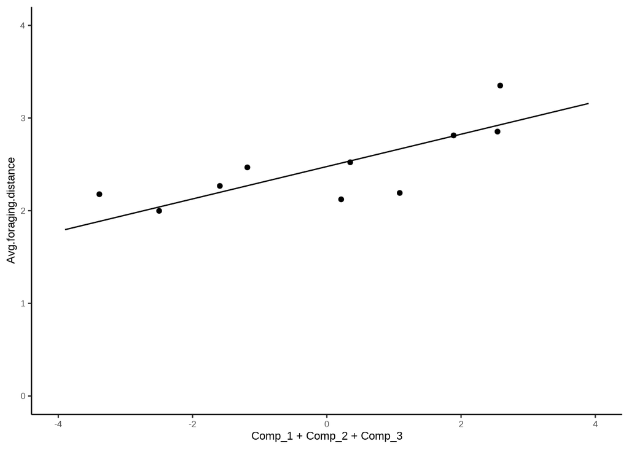

```r
newdat <- data_frame(
  Comp_1 = seq(-50, 140, 0.1),
  Comp_2 = seq(-50, 140, 0.1),
  Comp_3 = seq(-50, 140, 0.1),
)

newdat$fit <- predict(plsmodel.pc1_3, newdat, type = "response")

plotdata <- plsdata

ggplot(
  data = plotdata,
  aes(x = Comp_1 + Comp_2 + Comp_3, y = Avg.foraging.distance)
  ) +
  geom_point() +
  geom_line(
    data = newdat, aes(x = Comp_1 + Comp_2 + Comp_3, y = fit)
  ) +
  xlim(min(-4), max(4)) +
  ylim(0, 4)
```

PC1 looks like the only one significant so I will isolate this now.

```r
plsdata <- data.frame(
  Avg.foraging.distance = model.spring.2017$dataY,
  model.spring.2017$tt
)

plsmodel.pc1 <- lm(
  Avg.foraging.distance ~ Comp_1,
  plsdata
)

summary(plsmodel.pc1)
```

```
#>
#> Call:
#> lm(formula = Avg.foraging.distance ~ Comp_1, data = plsdata)
#>
#> Residuals:
#>      Min       1Q   Median       3Q      Max
#> -0.43374 -0.10517 -0.00525  0.22605  0.32586
#>
#> Coefficients:
#>             Estimate Std. Error t value Pr(>|t|)
#> (Intercept)  2.47617    0.08594  28.812 2.28e-09 ***
#> Comp_1       0.30459    0.08282   3.678  0.00624 **
#> ---
#> Signif. codes:  0 '***' 0.001 '**' 0.01 '*' 0.05 '.' 0.1 ' ' 1
#>
#> Residual standard error: 0.2718 on 8 degrees of freedom
#> Multiple R-squared:  0.6284, Adjusted R-squared:  0.5819
#> F-statistic: 13.53 on 1 and 8 DF,  p-value: 0.006239
```

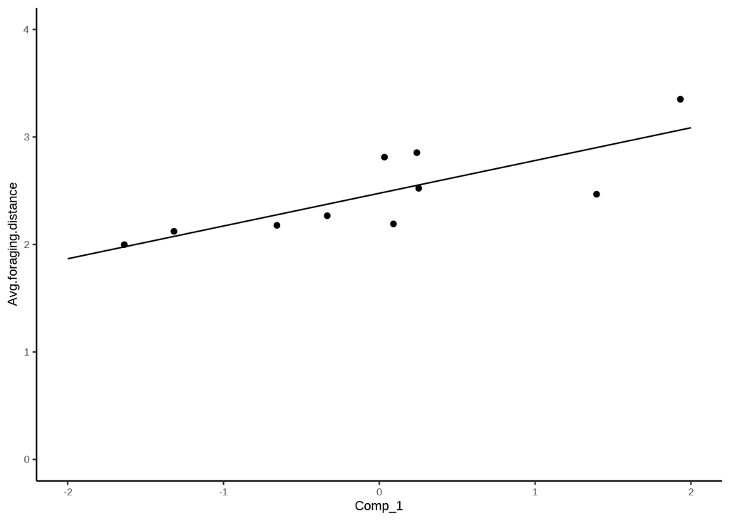

```r
newdat <- data_frame(
  Comp_1 = seq(-50, 140, 0.1),
)

newdat$fit <- predict(plsmodel.pc1, newdat, type = "response")

plotdata <- plsdata

ggplot(
  data = plotdata,
  aes(x = Comp_1, y = Avg.foraging.distance)
  ) +
  geom_point() +
  geom_line(
    data = newdat, aes(x = Comp_1, y = fit)
  ) +
  xlim(min(-2), max(2)) +
  ylim(0, 4)
```

```r
plsmodel.pc1_2 <- lm(
  Avg.foraging.distance ~ Comp_1 + Comp_2,
  plsdata
)

lrtest(plsmodel.pc1, plsmodel.pc1_2, plsmodel.pc1_3)
```

|  | #Df | LogLik | Df | Chisq | Pr(>Chisq) |
| --- | --- | --- | --- | --- | --- |
| 1 | 3 | -0.04593575 | NA | NA | NA |
| 2 | 4 | 1.54946258 | 1 | 3.190797 | 0.07405391 |
| 3 | 5 | 3.07873383 | 1 | 3.058543 | 0.08031368 |

Its close but PC1 on its own appears to be the best model from the LRT.

Here we get a significant positive relationship between PC1 and the foraging distance of urban honeybees. For every 1 unit increase in PC1, foraging distance increase by ~300m. This PC correlates positively with continuos central land and railway whilst correlating negatively with parks allotments and cemeteries and woodland.

```r
print(model.spring.2017$pp[, 1])
```

```
#>         continuous..central           dense.residential
#>                  0.50871484                 -0.04841116
#>          sparse.residential parks.allotments.cemeteries
#>                 -0.11104142                 -0.60273666
#>           amenity.grassland                     Railway
#>                 -0.31734830                  0.49787713
#>                    woodland                       water
#>                 -0.49621330                  0.33102397
```

```r
sqrt(1 / (ncol(urban.plsdata) - 1))
```

```
#> [1] 0.3535534
```

### Summer 2017

```r
# run model on summer 2017
model.summer.2017 <- plsRglm(
  Avg.foraging.distance ~ .,
  data = seasonal.foraging.df$Summer_2017,
  nt = ncol(seasonal.foraging.df$Summer_2017) - 1,
  verbose = FALSE
)

print(model.summer.2017)
```

```
#> Number of required components:
#> [1] 8
#> Number of successfully computed components:
#> [1] 8
#> Coefficients:
#>                                   [,1]
#> Intercept                   154.391213
#> continuous..central          -1.514872
#> dense.residential            -1.536742
#> sparse.residential           -1.534179
#> parks.allotments.cemeteries  -1.413298
#> amenity.grassland            -1.492916
#> Railway                      -1.519921
#> woodland                     -1.536620
#> water                        -1.494449
#> Information criteria and Fit statistics:
#>                 AIC     RSS_Y      R2_Y R2_residY RSS_residY  AIC.std  DoF.dof
#> Nb_Comp_0 12.790462 1.4102320        NA        NA   9.000000 31.32517 1.000000
#> Nb_Comp_1  9.517268 0.8322976 0.4098151 0.4098151   5.311664 28.05197 8.248275
#> Nb_Comp_2 10.564519 0.7566609 0.4634494 0.4634494   4.828956 29.09922 6.975404
#> Nb_Comp_3 12.108438 0.7229261 0.4873708 0.4873708   4.613663 30.64314 6.334828
#> Nb_Comp_4 14.036693 0.7177581 0.4910354 0.4910354   4.580681 32.57140 6.735488
#> Nb_Comp_5 15.952065 0.7117095 0.4953245 0.4953245   4.542079 34.48677 8.037515
#> Nb_Comp_6 17.904469 0.7083301 0.4977209 0.4977209   4.520512 36.43917 8.338239
#> Nb_Comp_7 19.904341 0.7083210 0.4977273 0.4977273   4.520454 38.43904 8.000081
#> Nb_Comp_8 21.859454 0.7051487 0.4999768 0.4999768   4.500208 40.39416 8.998294
#>           sigmahat.dof   AIC.dof   BIC.dof  GMDL.dof DoF.naive sigmahat.naive
#> Nb_Comp_0    0.3958440 0.1723617 0.1771030 -5.106005         1      0.3958440
#> Nb_Comp_1    0.5499672 0.5821908 0.6576799  8.622571         2      0.3225480
#> Nb_Comp_2    0.4336002 0.3379540 0.3776362  6.416517         3      0.3287771
#> Nb_Comp_3    0.3936526 0.2686247 0.2983282  5.118099         4      0.3471134
#> Nb_Comp_4    0.4102555 0.2985052 0.3328077  5.887224         5      0.3788821
#> Nb_Comp_5    0.4901436 0.4573587 0.5157860  8.164353         6      0.4218144
#> Nb_Comp_6    0.5158617 0.5146163 0.5817575  8.625596         7      0.4859115
#> Nb_Comp_7    0.4859150 0.4486174 0.5057735  8.100033         8      0.5951139
#> Nb_Comp_8    0.5935266 0.7044875 0.8004029  9.539178         9      0.8397313
#>           AIC.naive BIC.naive GMDL.naive
#> Nb_Comp_0 0.1723617 0.1771030 -5.1060052
#> Nb_Comp_1 0.1248446 0.1311407 -4.4183234
#> Nb_Comp_2 0.1405227 0.1503351 -2.0181720
#> Nb_Comp_3 0.1686828 0.1832659  0.3845557
#> Nb_Comp_4 0.2153274 0.2370457  2.7183382
#> Nb_Comp_5 0.2846838 0.3169867  4.8554831
#> Nb_Comp_6 0.4013871 0.4513974  6.7965357
#> Nb_Comp_7 0.6374889 0.7232199  8.5053673
#> Nb_Comp_8 1.3397825 1.5318132  9.8879043
```

PC1 accounts for ~41% of the variance in average foraging distance. Adding more PCs doesn’t do a lot to this, will all eight PCs explaining only 50% of the variance.

```r
plsdata <- data.frame(
  Avg.foraging.distance = model.summer.2017$dataY,
  model.summer.2017$tt
)

plsmodel.pc1 <- lm(
  Avg.foraging.distance ~ Comp_1,
  plsdata
)

summary(plsmodel.pc1)
```

```
#>
#> Call:
#> lm(formula = Avg.foraging.distance ~ Comp_1, data = plsdata)
#>
#> Residuals:
#>      Min       1Q   Median       3Q      Max
#> -0.37390 -0.18679 -0.08498  0.02275  0.59010
#>
#> Coefficients:
#>             Estimate Std. Error t value Pr(>|t|)
#> (Intercept)   2.5396     0.1020  24.899 7.24e-09 ***
#> Comp_1        0.2499     0.1060   2.357   0.0462 *
#> ---
#> Signif. codes:  0 '***' 0.001 '**' 0.01 '*' 0.05 '.' 0.1 ' ' 1
#>
#> Residual standard error: 0.3225 on 8 degrees of freedom
#> Multiple R-squared:  0.4098, Adjusted R-squared:  0.336
#> F-statistic: 5.555 on 1 and 8 DF,  p-value: 0.04618
```

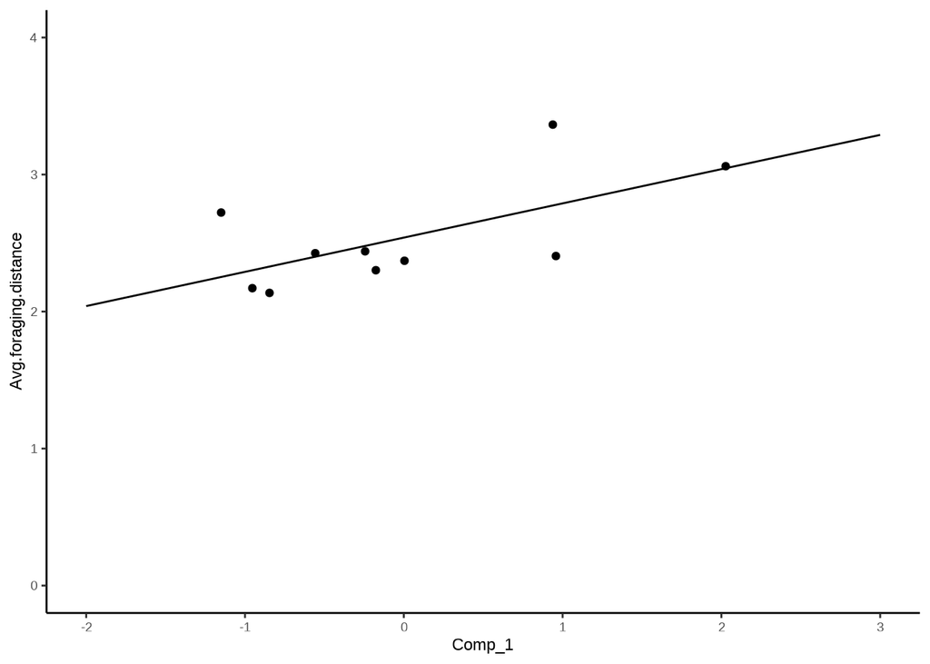

```r
newdat <- data_frame(
  Comp_1 = seq(-50, 140, 0.1),
)

newdat$fit <- predict(plsmodel.pc1, newdat, type = "response")

plotdata <- plsdata

ggplot(
  data = plotdata,
  aes(x = Comp_1, y = Avg.foraging.distance)
  ) +
  geom_point() +
  geom_line(
    data = newdat, aes(x = Comp_1, y = fit)
  ) +
  xlim(min(-2), max(3)) +
  ylim(0, 4)
```

Despite only showing a weak relationship ($R^2 = 0.41$) this is non the less significant, with every one unit increase in PC1 corresponding to an increase of ~250 meters in foraging distance.

```r
print(model.summer.2017$pp[, 1])
```

```
#>         continuous..central           dense.residential
#>                  0.52238141                  0.19579818
#>          sparse.residential parks.allotments.cemeteries
#>                 -0.48276539                  0.63266544
#>           amenity.grassland                     Railway
#>                 -0.37350281                 -0.39976671
#>                    woodland                       water
#>                  0.11609976                  0.08680029
```

```r
sqrt(1 / (ncol(urban.plsdata) - 1))
```

```
#> [1] 0.3535534
```

## Agri-rural by season

### Spring 2017

```r
# subset data by season and year and prepare for the model
rural.df$year_season <- paste(rural.df$season, rural.df$Year, sep = "_")
seasonal.foraging.df <- purrr::map(
  unique(rural.df$year_season),
  ~ {
    rural.df %>%
      filter(year_season == .x) %>%
      ungroup() %>%
      select(-LU, -site, -Year, -season, - year_season)
  }
)
names(seasonal.foraging.df) <- unique(rural.df$year_season)

# run model on spring 2017
model.spring.2017 <- plsRglm(
  Avg.foraging.distance ~ .,
  data = seasonal.foraging.df$Spring_2017,
  nt = ncol(seasonal.foraging.df$Spring_2017) - 1,
  verbose = FALSE
)

print(model.spring.2017)
```

```
#> Number of required components:
#> [1] 10
#> Number of successfully computed components:
#> [1] 9
#> Coefficients:
#>                                                [,1]
#> Intercept                               0.220623049
#> woodland                                0.064877910
#> Non.agricultural.unmanaged.green.space  0.001101437
#> Non.agricultural.managed.green.space    0.570104269
#> arable                                  0.003417986
#> pasture                                 0.099660296
#> other.agricultural                      2.159464457
#> fruit                                  -0.044912897
#> OSR                                    -0.521490884
#> built.up.area                          -0.245608949
#> water                                   1.692936523
#> Information criteria and Fit statistics:
#>                   AIC        RSS_Y      R2_Y R2_residY   RSS_residY     AIC.std
#> Nb_Comp_0   26.287199 5.438090e+00        NA        NA 9.000000e+00   31.325166
#> Nb_Comp_1   10.329969 9.027631e-01 0.8339926 0.8339926 1.494066e+00   15.367935
#> Nb_Comp_2    9.393701 6.730593e-01 0.8762324 0.8762324 1.113908e+00   14.431667
#> Nb_Comp_3    9.423638 5.527065e-01 0.8983639 0.8983639 9.147253e-01   14.461604
#> Nb_Comp_4    9.479917 4.550717e-01 0.9163177 0.9163177 7.531403e-01   14.517883
#> Nb_Comp_5   10.222526 4.013027e-01 0.9262052 0.9262052 6.641530e-01   15.260493
#> Nb_Comp_6   10.357723 3.330310e-01 0.9387596 0.9387596 5.511639e-01   15.395689
#> Nb_Comp_7   11.706796 3.120436e-01 0.9426189 0.9426189 5.164299e-01   16.744762
#> Nb_Comp_8    4.801203 1.280708e-01 0.9764493 0.9764493 2.119563e-01    9.839169
#> Nb_Comp_9 -647.076239 5.127596e-30 1.0000000 1.0000000 8.610598e-30 -641.892670
#>            DoF.dof sigmahat.dof      AIC.dof      BIC.dof   GMDL.dof DoF.naive
#> Nb_Comp_0 1.000000 7.773238e-01 6.646555e-01 6.829387e-01   1.183436         1
#> Nb_Comp_1 9.000000 6.718494e-01 9.027631e-01 1.025686e+00  11.760027         2
#> Nb_Comp_2 4.458883 3.207751e-01 1.590668e-01 1.729495e-01   1.874624         3
#> Nb_Comp_3 7.056049 3.743532e-01 2.530380e-01 2.829588e-01   7.758195         4
#> Nb_Comp_4 9.000000 4.770072e-01 4.550717e-01 5.170358e-01  11.436878         5
#> Nb_Comp_5 8.451712 3.968367e-01 3.063243e-01 3.465975e-01  10.342222         6
#> Nb_Comp_6 7.365716 3.027143e-01 1.682959e-01 1.887194e-01   7.769385         7
#> Nb_Comp_7 7.200384 2.865747e-01 1.494707e-01 1.673635e-01   7.281675         8
#> Nb_Comp_8 9.000000 2.530522e-01 1.280708e-01 1.455094e-01  10.817027         9
#> Nb_Comp_9 9.000000 1.601186e-15 5.127596e-30 5.825786e-30 -21.871341        10
#>           sigmahat.naive AIC.naive BIC.naive GMDL.naive
#> Nb_Comp_0      0.7773238 0.6646555 0.6829387  1.1834360
#> Nb_Comp_1      0.3359247 0.1354145 0.1422435 -3.6256976
#> Nb_Comp_2      0.3100828 0.1249967 0.1337249 -1.7250691
#> Nb_Comp_3      0.3035091 0.1289649 0.1401142  0.5175772
#> Nb_Comp_4      0.3016858 0.1365215 0.1502913  2.7543635
#> Nb_Comp_5      0.3167423 0.1605211 0.1787353  5.1211062
#> Nb_Comp_6      0.3331821 0.1887176 0.2122306  7.3134172
#> Nb_Comp_7      0.3949959 0.2808392 0.3186071  9.5708655
#> Nb_Comp_8      0.3578699 0.2433346 0.2782117 11.1636008
#> Nb_Comp_9            Inf       Inf       Inf        Inf
```

The first 2 PCs explain ~88% of the variation in the average foraging distance.

```r
plsdata <- data.frame(
  Avg.foraging.distance = model.spring.2017$dataY,
  model.spring.2017$tt
)

plsmodel.pc1_2 <- lm(
  Avg.foraging.distance ~ Comp_1 + Comp_2,
  plsdata
)

summary(plsmodel.pc1_2 )
```

```
#>
#> Call:
#> lm(formula = Avg.foraging.distance ~ Comp_1 + Comp_2, data = plsdata)
#>
#> Residuals:
#>      Min       1Q   Median       3Q      Max
#> -0.57372 -0.10971  0.07398  0.20330  0.28047
#>
#> Coefficients:
#>             Estimate Std. Error t value Pr(>|t|)
#> (Intercept)  3.15168    0.09806  32.141  7.3e-09 ***
#> Comp_1       0.64024    0.09322   6.868 0.000238 ***
#> Comp_2       0.16953    0.10968   1.546 0.166111
#> ---
#> Signif. codes:  0 '***' 0.001 '**' 0.01 '*' 0.05 '.' 0.1 ' ' 1
#>
#> Residual standard error: 0.3101 on 7 degrees of freedom
#> Multiple R-squared:  0.8762, Adjusted R-squared:  0.8409
#> F-statistic: 24.78 on 2 and 7 DF,  p-value: 0.000667
```

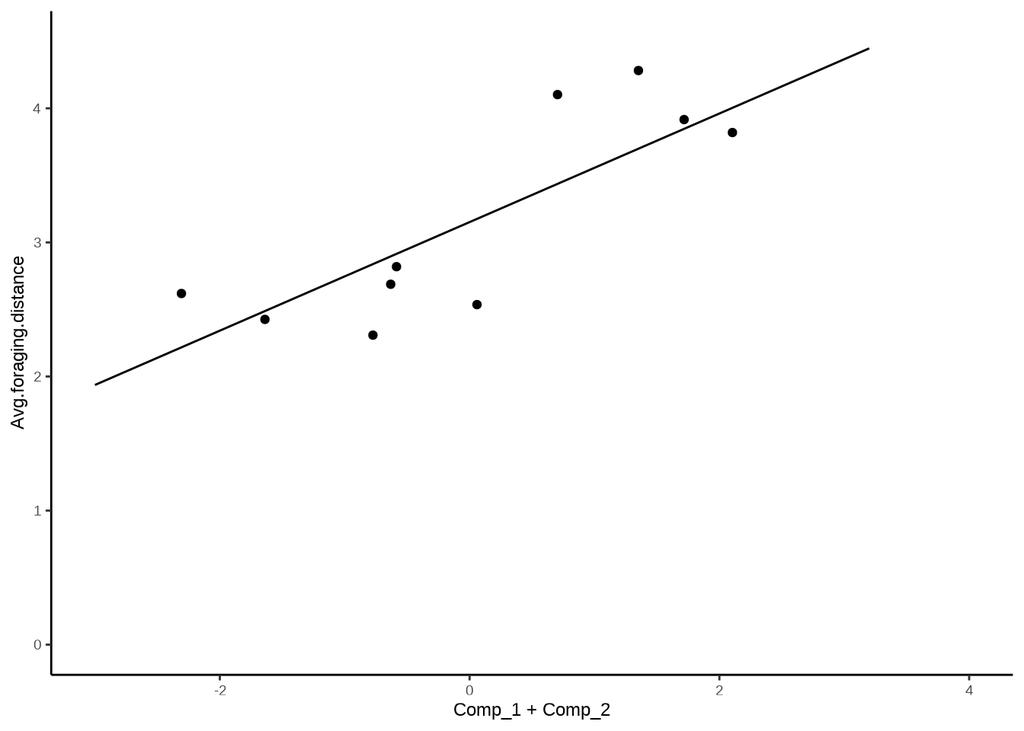

```r
newdat <- data_frame(
  Comp_1 = seq(-50, 140, 0.1),
  Comp_2 = seq(-50, 140, 0.1),
  Comp_3 = seq(-50, 140, 0.1),
)

newdat$fit <- predict(plsmodel.pc1_2, newdat, type = "response")

plotdata <- plsdata

ggplot(
  data = plotdata,
  aes(x = Comp_1 + Comp_2, y = Avg.foraging.distance)
  ) +
  geom_point() +
  geom_line(
    data = newdat, aes(x = Comp_1 + Comp_2, y = fit)
  ) +
  xlim(min(-3), max(4)) +
  ylim(0, 4.5)
```

The intercept is significantly different to 0 but only PC1 looks significant. Lets isolate it to have a look.

```r
plsdata <- data.frame(
  Avg.foraging.distance = model.spring.2017$dataY,
  model.spring.2017$tt
)

plsmodel.pc1 <- lm(
  Avg.foraging.distance ~ Comp_1,
  plsdata
)

summary(plsmodel.pc1)
```

```
#>
#> Call:
#> lm(formula = Avg.foraging.distance ~ Comp_1, data = plsdata)
#>
#> Residuals:
#>     Min      1Q  Median      3Q     Max
#> -0.6552 -0.1681  0.1155  0.2532  0.2811
#>
#> Coefficients:
#>             Estimate Std. Error t value Pr(>|t|)
#> (Intercept)   3.1517     0.1062   29.67 1.81e-09 ***
#> Comp_1        0.6402     0.1010    6.34 0.000223 ***
#> ---
#> Signif. codes:  0 '***' 0.001 '**' 0.01 '*' 0.05 '.' 0.1 ' ' 1
#>
#> Residual standard error: 0.3359 on 8 degrees of freedom
#> Multiple R-squared:  0.834,  Adjusted R-squared:  0.8132
#> F-statistic: 40.19 on 1 and 8 DF,  p-value: 0.0002231
```

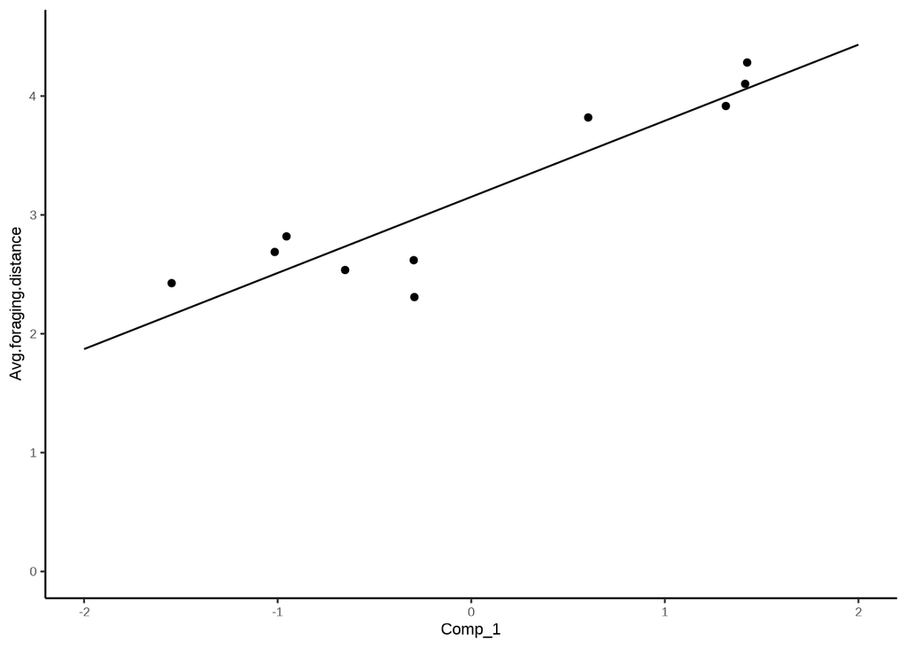

```r
newdat <- data_frame(
  Comp_1 = seq(-50, 140, 0.1),
  Comp_2 = seq(-50, 140, 0.1),
  Comp_3 = seq(-50, 140, 0.1),
)

newdat$fit <- predict(plsmodel.pc1, newdat, type = "response")

plotdata <- plsdata

ggplot(
  data = plotdata,
  aes(x = Comp_1, y = Avg.foraging.distance)
  ) +
  geom_point() +
  geom_line(
    data = newdat, aes(x = Comp_1, y = fit)
  ) +
  xlim(min(-2), max(2)) +
  ylim(0, 4.5)
```

```r
lrtest(plsmodel.pc1, plsmodel.pc1_2)
```

|  | #Df | LogLik | Df | Chisq | Pr(>Chisq) |
| --- | --- | --- | --- | --- | --- |
| 1 | 3 | -2.1649845 | NA | NA | NA |
| 2 | 4 | -0.6968504 | 1 | 2.936268 | 0.08661062 |

PC1 on its own provides the best fit and explains ~83% of the variation in average foraging distance. There is a significant positive relationship where by every one unit increase in PC1 increases the foraging distance by ~640 meters. This PC is characterised by a positive correlation with arable land and Non.agricultural unmanaged green space and a negative correlation with pasture and built up areas.

```r
print(model.spring.2017$pp[, 1])
```

```
#>                               woodland Non.agricultural.unmanaged.green.space
#>                            -0.18270305                             0.33724331
#>   Non.agricultural.managed.green.space                                 arable
#>                             0.14876130                             0.50211496
#>                                pasture                     other.agricultural
#>                            -0.43492559                            -0.02008243
#>                                  fruit                                    OSR
#>                             0.26902286                             0.19202366
#>                          built.up.area                                  water
#>                            -0.49327943                             0.27035032
```

```r
sqrt(1 / (ncol(rural.plsdata) - 1))
```

```
#> [1] 0.3162278
```

### Summer 2017

```r
# run model on summer 2017
model.summer.2017 <- plsRglm(
  Avg.foraging.distance ~ .,
  data = seasonal.foraging.df$Summer_2017,
  nt = ncol(seasonal.foraging.df$Summer_2017) - 1,
  verbose = FALSE
)

print(model.summer.2017)
```

```
#> Number of required components:
#> [1] 10
#> Number of successfully computed components:
#> [1] 9
#> Coefficients:
#>                                               [,1]
#> Intercept                              -3.25498917
#> woodland                                0.12408011
#> Non.agricultural.unmanaged.green.space  0.09935972
#> Non.agricultural.managed.green.space    1.33522063
#> arable                                 -0.02984973
#> pasture                                 0.27091854
#> other.agricultural                      5.63186039
#> fruit                                   0.45520381
#> OSR                                    -1.64377306
#> built.up.area                          -0.53455543
#> water                                  -7.80282574
#> Information criteria and Fit statistics:
#>                  AIC        RSS_Y      R2_Y R2_residY   RSS_residY    AIC.std
#> Nb_Comp_0   23.17901 3.985286e+00        NA        NA 9.000000e+00   31.32517
#> Nb_Comp_1   18.59415 2.062921e+00 0.4823656 0.4823656 4.658710e+00   26.74030
#> Nb_Comp_2   17.08646 1.452598e+00 0.6355096 0.6355096 3.280414e+00   25.23261
#> Nb_Comp_3   16.83326 1.159552e+00 0.7090417 0.7090417 2.618625e+00   24.97941
#> Nb_Comp_4   18.46522 1.117652e+00 0.7195554 0.7195554 2.524001e+00   26.61137
#> Nb_Comp_5   19.84130 1.050050e+00 0.7365183 0.7365183 2.371336e+00   27.98745
#> Nb_Comp_6   21.75162 1.040675e+00 0.7388706 0.7388706 2.350164e+00   29.89777
#> Nb_Comp_7   23.68427 1.033691e+00 0.7406232 0.7406232 2.334391e+00   31.83043
#> Nb_Comp_8   24.49525 9.178082e-01 0.7697008 0.7697008 2.072693e+00   32.64141
#> Nb_Comp_9 -635.46880 1.636886e-29 1.0000000 1.0000000 3.771322e-29 -627.12250
#>            DoF.dof sigmahat.dof      AIC.dof      BIC.dof    GMDL.dof DoF.naive
#> Nb_Comp_0 1.000000 6.654393e-01 4.870905e-01 5.004892e-01  -0.2309157         1
#> Nb_Comp_1 5.694333 6.235500e-01 6.491000e-01 7.160935e-01   7.2247048         2
#> Nb_Comp_2 7.596541 6.532997e-01 7.937014e-01 8.918057e-01   9.8721764         3
#> Nb_Comp_3 6.795595 5.251614e-01 4.907927e-01 5.475028e-01   8.1928461         4
#> Nb_Comp_4 8.066471 6.172457e-01 7.264177e-01 8.194101e-01  10.3368126         5
#> Nb_Comp_5 8.268643 6.200343e-01 7.407686e-01 8.369549e-01  10.5962392         6
#> Nb_Comp_6 8.164843 6.058555e-01 7.034664e-01 7.941509e-01  10.4271752         7
#> Nb_Comp_7 7.946603 5.818401e-01 6.414144e-01 7.228166e-01  10.0701712         8
#> Nb_Comp_8 8.448910 5.998091e-01 6.997153e-01 7.916913e-01  10.7694365         9
#> Nb_Comp_9 9.000000 2.860845e-15 1.636886e-29 1.859770e-29 -21.4892798        10
#>           sigmahat.naive AIC.naive BIC.naive GMDL.naive
#> Nb_Comp_0      0.6654393 0.4870905 0.5004892 -0.2309157
#> Nb_Comp_1      0.5078042 0.3094381 0.3250434 -0.3762329
#> Nb_Comp_2      0.4555371 0.2697683 0.2886054  0.8890665
#> Nb_Comp_3      0.4396119 0.2705621 0.2939530  2.6396355
#> Nb_Comp_4      0.4727900 0.3352955 0.3691140  4.8733711
#> Nb_Comp_5      0.5123597 0.4200200 0.4676794  6.8925781
#> Nb_Comp_6      0.5889751 0.5897159 0.6631909  8.8428805
#> Nb_Comp_7      0.7189195 0.9303216 1.0554333 10.5628105
#> Nb_Comp_8      0.9580231 1.7438355 1.9937791 11.9141090
#> Nb_Comp_9            Inf       Inf       Inf        Inf
```

The first three PCs collectively explain ~71% of the variation in average foraging distances.

```r
plsdata <- data.frame(
  Avg.foraging.distance = model.summer.2017$dataY,
  model.summer.2017$tt
)

plsmodel.pc1_3 <- lm(
  Avg.foraging.distance ~ Comp_1 + Comp_2 + Comp_3,
  plsdata
)

summary(plsmodel.pc1_3)
```

```
#>
#> Call:
#> lm(formula = Avg.foraging.distance ~ Comp_1 + Comp_2 + Comp_3,
#>     data = plsdata)
#>
#> Residuals:
#>      Min       1Q   Median       3Q      Max
#> -0.71320 -0.05968  0.00412  0.08869  0.69835
#>
#> Coefficients:
#>             Estimate Std. Error t value Pr(>|t|)
#> (Intercept)   3.1027     0.1390  22.319 5.29e-07 ***
#> Comp_1        0.3308     0.1049   3.154   0.0197 *
#> Comp_2        0.2265     0.1274   1.777   0.1259
#> Comp_3        0.2344     0.1903   1.231   0.2642
#> ---
#> Signif. codes:  0 '***' 0.001 '**' 0.01 '*' 0.05 '.' 0.1 ' ' 1
#>
#> Residual standard error: 0.4396 on 6 degrees of freedom
#> Multiple R-squared:  0.709,  Adjusted R-squared:  0.5636
#> F-statistic: 4.874 on 3 and 6 DF,  p-value: 0.04761
```

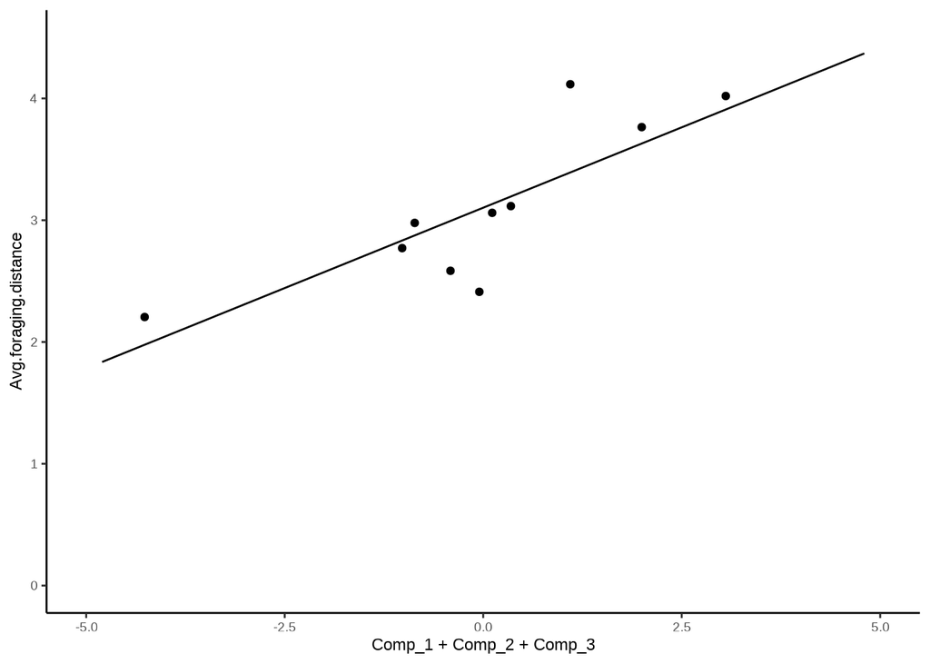

```r
newdat <- data_frame(
  Comp_1 = seq(-50, 140, 0.1),
  Comp_2 = seq(-50, 140, 0.1),
  Comp_3 = seq(-50, 140, 0.1),
)

newdat$fit <- predict(plsmodel.pc1_3, newdat, type = "response")

plotdata <- plsdata

ggplot(
  data = plotdata,
  aes(x = Comp_1 + Comp_2 + Comp_3, y = Avg.foraging.distance)
  ) +
  geom_point() +
  geom_line(
    data = newdat, aes(x = Comp_1 + Comp_2 + Comp_3, y = fit)
  ) +
  xlim(min(-5), max(5)) +
  ylim(0, 4.5)
```

Both the intercept and PC1 looks significant so I will isolate them.

```r
plsdata <- data.frame(
  Avg.foraging.distance = model.summer.2017$dataY,
  model.summer.2017$tt
)

plsmodel.pc1 <- lm(
  Avg.foraging.distance ~ Comp_1,
  plsdata
)

summary(plsmodel.pc1)
```

```
#>
#> Call:
#> lm(formula = Avg.foraging.distance ~ Comp_1, data = plsdata)
#>
#> Residuals:
#>     Min      1Q  Median      3Q     Max
#> -0.7786 -0.2885 -0.1100  0.3553  0.8319
#>
#> Coefficients:
#>             Estimate Std. Error t value Pr(>|t|)
#> (Intercept)   3.1027     0.1606   19.32 5.34e-08 ***
#> Comp_1        0.3308     0.1212    2.73   0.0258 *
#> ---
#> Signif. codes:  0 '***' 0.001 '**' 0.01 '*' 0.05 '.' 0.1 ' ' 1
#>
#> Residual standard error: 0.5078 on 8 degrees of freedom
#> Multiple R-squared:  0.4824, Adjusted R-squared:  0.4177
#> F-statistic: 7.455 on 1 and 8 DF,  p-value: 0.02583
```